# Forecasting # of visitors from India

### CMV

```r
source("source.R")
TS_SE1 <- read.csv("India.csv")
Visitors <- TS_SE1$India
Quarter <- TS_SE1$Month
Season <- max(Quarter)
Period <- TS_SE1$period
t  = Period -1
n <- length(Visitors)
CMV_SI <- Center_Moving_Average(Visitors, Quarter, Season)
cat("# # # # The Centered moving average seasonal index # # # ","\n")
```

```
# # # # The Centered moving average seasonal index # # #
```

```r
print(CMV_SI)
```

```
 [1] 0.7963203 0.9000374 1.1482949 1.0418228 1.0672606 1.1127059 0.9381149 1.0342431 1.0969585
[10] 0.9883135 1.0301748 0.8457534
```

### Forecast by seasonal index

```
### Linear Model ###
Call:
lm(formula = Des_x ~ t)

Residuals:
    Min      1Q  Median      3Q     Max
-668.01 -169.61    2.15  143.92  761.27

Coefficients:
            Estimate Std. Error t value Pr(>|t|)
(Intercept) 1746.691     55.059   31.72   <2e-16 ***
t             16.937      1.001   16.92   <2e-16 ***
---
Signif. codes:  0 ‘***’ 0.001 ‘**’ 0.01 ‘*’ 0.05 ‘.’ 0.1 ‘ ’ 1

Residual standard error: 271.8 on 94 degrees of freedom
Multiple R-squared:  0.7527,    Adjusted R-squared:  0.7501
F-statistic: 286.2 on 1 and 94 DF,  p-value: < 2.2e-16


    Shapiro-Wilk normality test

data:  Standard_E
W = 0.9766, p-value = 0.08338

run test:[1] 0.8374104
The Outliers[1] 38 40 41 74 94
influential observations:[1] "no influential observations"
mean_y: 2551.194



deseasonalized data:
 [1] 2152.239 1765.965 2090.362 1854.496 1906.180 1984.188 2021.987 1879.981 1814.597 2255.462
[11] 1788.739 1963.866 1788.691 1912.455 2081.835 1710.430 2070.270 1992.283 1967.627 1950.923
[21] 2147.377 1681.041 2090.056 1907.234 1865.524 2096.691 1828.134 1672.721 1828.693 2356.540
[31] 1879.293 1972.206 2157.423 2382.123 2061.317 2214.388 2358.374 3069.095 2258.785 3168.501
[41] 3145.971 2225.003 2601.500 2334.014 2343.278 2114.357 2822.446 2676.079 2808.124 3012.476
[51] 2395.229 2921.944 2756.713 2586.224 2766.521 2780.952 2948.562 2825.438 2672.658 2681.838
[61] 2894.326 2389.670 2942.070 3029.268 2394.803 2941.374 2967.458 3031.616 2703.686 3314.307
[71] 2854.667 2959.236 3125.759 2315.077 3101.965 2777.877 2831.465 2747.104 2968.428 3418.254
[81] 3238.647 2839.882 3328.413 3325.902 3047.053 2913.618 3470.790 2938.381 3139.590 3395.684
[91] 3422.720 3367.412 3217.299 4008.722 3256.132 2928.521
```

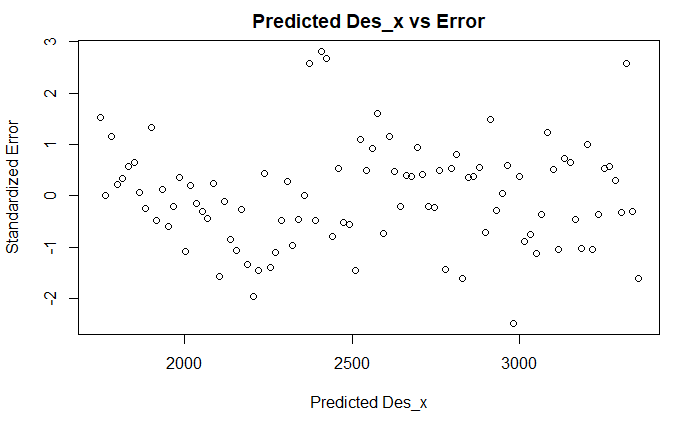

```r
Forecast_Visitors_CMV= Forecast_by_SI(Visitors, Quarter, Season, CMV_SI, t)
```

```r
cat("# # # # The Forecast_Visitors_y # # # ","\n")
```

```
# # # # The Forecast_Visitors_y # # #
```

```r
print(Forecast_Visitors_CMV)
```

```
  [1] 1864.174 1962.399 1670.374 1859.054 1990.364 1809.973 1904.085 1577.541 1498.823 1709.282
 [11] 2200.202 2013.840 2081.087 2188.548 1861.039 2069.256 2213.313 2010.841 2113.460 1749.434
 [21] 1660.669 1892.208 2433.584 2225.583 2298.001 2414.698 2051.705 2279.459 2436.262 2211.708
 [31] 2322.836 1921.328 1822.516 2075.134 2666.967 2437.326 2514.914 2640.847 2242.370 2489.661
 [41] 2659.211 2412.576 2532.212 2093.221 1984.362 2258.060 2900.350 2649.069 2731.827 2866.997
 [51] 2433.035 2699.864 2882.160 2613.443 2741.587 2265.114 2146.208 2440.986 3133.733 2860.812
 [61] 2948.740 3093.146 2623.700 2910.066 3105.108 2814.311 2950.963 2437.008 2308.055 2623.912
 [71] 3367.115 3072.555 3165.653 3319.296 2814.365 3120.269 3328.057 3015.179 3160.339 2608.901
 [81] 2469.901 2806.839 3600.498 3284.298 3382.566 3545.445 3005.030 3330.471 3551.006 3216.046
 [91] 3369.714 2780.794 2631.748 2989.765 3833.881 3496.041 2685.696 3050.740 3911.675 3566.622
[101] 3671.783 3846.978 3259.250 3610.741 3848.272 3483.870 3648.882 3009.985
```

```r
t2 = c(t,n,n+1,n+2,n+3,n+4,n+5,n+6,n+7,n+8,n+9,n+10,n+11)
lines(t,Visitors, col = "blue", main = "Visitorsagainst Period", xlab = "Period", ylab = "Tourists")
lines(t, Visitors, type="o", col = "blue")    #actual
```

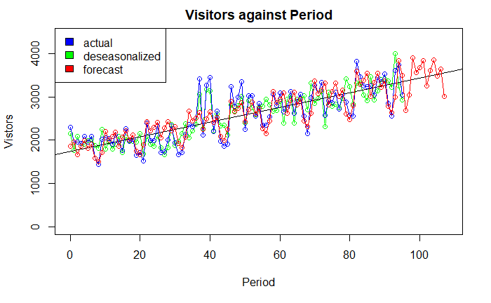

```r
lines(t2,Forecast_Visitors_CMV, type="o", col = "red")  #forecast
legend("topleft", c("actual", "deseasonalized", "forecast"), fill=c("blue","green", "red"))
```

*Residual analysis:*  
1.normality test  
H0: Errors are normally distributed.  
H1: Errors are not normally distributed.  
Since pvalue = 0.08338 > 0.05, we do not reject H0.

2..Homoscedasticity & Heteroscedasticity  
H0: The variance of e is the same for all values of x.  
H1: The variance of e is not the same for all values of x.  
According to the plot, there is no sign of heteroscedasticity.

3.Dependence of the Error Variable  
H0 : Randomness exists.  
H1 : Randomness does not exist.  
Since pvalue = 0.8374104 > 0.05, we do not reject H0.

*Assessment*  
The standard error of estimate (271.8) is samll compared to mean_y (2551.194). We can conclude that the model fit the data.

r^2 = 75.27% of the variation in the fund value is explained by the variation in Des_x. The rest(24.73%) remains unexplained by this model.

Testing the coefficients beta1.  
H0: beta1 = 0, H1: beta1 != 0  
Since p-value < 2.2e-16 , we are 95% confident to reject H0. There is overwhelming evidence that t affects Des_x.

[output not shown]

[output not shown]

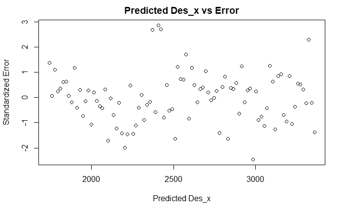

```r
cat("# # # # The Forecast_Visitors_y # # # ","\n")
```

```
# # # # The Forecast_Visitors_y # # #
```

```r
print(Forecast_Visitors_SLR)
```

```
  [1] 1900.044 1945.558 1686.902 1853.554 1985.772 1803.108 1909.990 1573.354 1483.017 1742.546
 [11] 2176.218 1967.199 2122.144 2170.784 1880.320 2064.068 2209.188 2004.089 2120.924 1745.526
 [21] 1643.838 1929.818 2408.021 2174.894 2344.244 2396.010 2073.737 2274.581 2432.604 2205.069
 [31] 2331.858 1917.699 1804.658 2117.090 2639.823 2382.589 2566.344 2621.237 2267.154 2485.095
 [41] 2656.020 2406.049 2542.793 2089.872 1965.479 2304.361 2871.626 2590.284 2788.444 2846.463
 [51] 2460.571 2695.609 2879.436 2607.029 2753.727 2262.044 2126.299 2491.633 3103.429 2797.979
 [61] 3010.544 3071.689 2653.989 2906.123 3102.851 2808.010 2964.661 2434.217 2287.120 2678.905
 [71] 3335.231 3005.674 3232.645 3296.916 2847.406 3116.637 3326.267 3008.990 3175.596 2606.390
 [81] 2447.940 2866.177 3567.034 3213.369 3454.745 3522.142 3040.823 3327.151 3549.683 3209.970
 [91] 3386.530 2778.562 2608.761 3053.449 3798.837 3421.064 2662.367 3115.873 3876.104 3490.296
[101] 3750.878 3822.444 3298.713 3607.836 3847.571 3477.944 3667.776 3008.126
```

```r
write.csv(Forecast_Visitors_SLR,"../../temp.csv")
#plot(t,Visitors, col = "blue", main = "Visitors against Period", xlab = "Period", ylab = "Visitors", xlim=range(t2, t2+1), ylim=range(Forecast_Visitors_SLR,0))
lines(t, Visitors, type="o", col = "blue")    #actual
lines(t2,Forecast_Visitors_SLR, type="o", col = "red")  #forecast
```

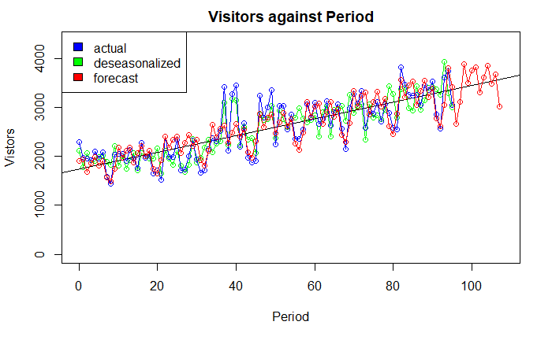

```r
legend("topleft", c("actual", "deseasonalized", "forecast"), fill=c("blue","green", "red"))
```

*Residual analysis:*  
1. normality test  
H0: Errors are normally distributed.  
H1: Errors are not normally distributed.  
Since pvalue = 0.1295 > 0.05, we do not reject H0.

2..Homoscedasticity & Heteroscedasticity  
H0: The variance of e is the same for all values of x.  
H1: The variance of e is not the same for all values of x.  
According to the plot, there is no sign of heteroscedasticity.

3.Dependence of the Error Variable  
H0 : Randomness exists.  
H1 : Randomness does not exist.  
Since pvalue = 0.8374 > 0.05, we do not reject H0.

*Assessment*  
The standard error of estimate (268.7) is samll compared to mean_y (2550.98 ). We can conclude that the model fit the data.

r^2 = 75.81% of the variation in the fund value is explained by the variation in Des_x. The rest(24.19%) remains unexplained by this model.

Testing the coefficients beta1.  
H0: beta1 = 0, H1: beta1 != 0  
Since p-value <2e-16 , we are 95% confident to reject H0. There is overwhelming evidence that t affects Des_x.  
——————————————————————————————-

The # of visitors forecast for the next 12 months are 2662.367, 3115.873, 3876.104, 3490.296, 3750.878, 3822.444, 3298.713, 3607.836, 3847.571, 3477.944, 3667.776, 3008.126 respectively.

## Regression model by indicator variables

### The Regression Model

y = beta0 + beta1*t + beta2*Q1 + beta3*Q2 + beta4*Q3 + beta5*Q4 +beta6*Q5 +beta7*Q6 +beta8*Q7 +beta*9Q8 +beta10*Q9 +beta11*Q10 +vbeta12Q*11 +e where t = time in chronological order Qi = indicator variable (0, 1).

### Dummy as Quarter

```r
Dummy_I <- Season - 1    # n-1 indicator variables
Q <- matrix(nrow =n, ncol = Dummy_I)
Dummy_Name <- vector("character", length = Dummy_I)
for(i in 1:Dummy_I){
  Dummy_Name[i] <- paste0("Q", i)
}
colnames(Q) <- Dummy_Name
for(i in 1:n){
  for(j in 1:Dummy_I){
    if(Quarter[i] == j){
      Q[i,j] <- 1
    } else {
      Q[i,j] <- 0
    }
  }
}
```

### build the model

```r
Data.Visitors <- cbind(t, Q)  #t, Q1, Q2, Q3...
linearModelVar1 <- lm(Visitors ~ Data.Visitors)
cat("\n# # # # The regression model # # # ","\n")
```

```
# # # # The regression model # # #
```

```r
print(summary(linearModelVar1))
```

```
Call:
lm(formula = Visitors ~ Data.Visitors)

Residuals:
    Min      1Q  Median      3Q     Max
-636.84 -192.79   12.82  153.06  807.07

Coefficients:
                 Estimate Std. Error t value Pr(>|t|)
(Intercept)      1368.774    115.425  11.859  < 2e-16 ***
Data.Visitorst     16.803      1.078  15.593  < 2e-16 ***
Data.VisitorsQ1  -161.303    145.158  -1.111  0.26968
Data.VisitorsQ2   184.269    145.170   1.269  0.20787
Data.VisitorsQ3   753.716    145.190   5.191 1.46e-06 ***
Data.VisitorsQ4   430.788    145.218   2.966  0.00393 **
Data.VisitorsQ5   598.997    145.350   4.121 8.88e-05 ***
Data.VisitorsQ6   617.443    145.298   4.250 5.57e-05 ***
Data.VisitorsQ7   257.015    145.254   1.769  0.08050 .
Data.VisitorsQ8   470.212    145.218   3.238  0.00173 **
Data.VisitorsQ9   610.784    145.190   4.207 6.51e-05 ***
Data.VisitorsQ10  340.481    145.170   2.345  0.02139 *
Data.VisitorsQ11  476.803    145.158   3.285  0.00150 **
---
Signif. codes:  0 ‘***’ 0.001 ‘**’ 0.01 ‘*’ 0.05 ‘.’ 0.1 ‘ ’ 1

Residual standard error: 290.3 on 83 degrees of freedom
Multiple R-squared:  0.7911,    Adjusted R-squared:  0.7609
F-statistic: 26.19 on 12 and 83 DF,  p-value: < 2.2e-16
```

```r
cat(" ","\n")
```

```r
ANOVA_T_lm <- anova(linearModelVar1)
cat("# # # # The ANOVA Table # # # ","\n")
```

```
# # # # The ANOVA Table # # #
```

```r
print(ANOVA_T_lm)
```

```
Analysis of Variance Table

Response: Visitors
              Df   Sum Sq Mean Sq F value    Pr(>F)
Data.Visitors 12 26487419 2207285   26.19 < 2.2e-16 ***
Residuals     83  6995121   84279
---
Signif. codes:  0 ‘***’ 0.001 ‘**’ 0.01 ‘*’ 0.05 ‘.’ 0.1 ‘ ’ 1
```

```r
#residual analysis
SE_1 <- standarized_errors_MR(Visitors, Data.Visitors)[,1]
h_1 <- standarized_errors_MR(Visitors, Data.Visitors)[,2]
D_1 <- standarized_errors_MR(Visitors, Data.Visitors)[,3]
print(shapiro.test(SE_1) )          # normality
```

```
    Shapiro-Wilk normality test

data:  SE_1
W = 0.97095, p-value = 0.03138
```

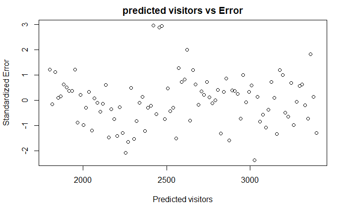

```r
b0<- coef(linearModelVar1)[1]             # Homoscedasticity & Heteroscedasticity
b1 <- coef(linearModelVar1)[2]
b2 <- coef(linearModelVar1)[3]
b3 <- coef(linearModelVar1)[4]
b4 <- coef(linearModelVar1)[5]
b5 <- coef(linearModelVar1)[6]
b6 <- coef(linearModelVar1)[7]
b7 <- coef(linearModelVar1)[8]
b8 <- coef(linearModelVar1)[9]
b9 <- coef(linearModelVar1)[10]
b10 <- coef(linearModelVar1)[11]
b11 <- coef(linearModelVar1)[12]
b12 <- coef(linearModelVar1)[13]
yhat <- vector("double", length = n)
for(i in 1:n) {
       yhat <- b0 + b1 *t + b2 *Q[i,1] + b3 *Q[i,2] + b4 *Q[i,3]+ b5 *Q[i,4]+ b6 *Q[i,5]+ b7 *Q[i,6]+ b8 *Q[i,7]+ b9 *Q[i,8]+ b10 *Q[i,9]+ b11 *Q[i,10]+ b12 *Q[i,11]
}
plot(x = yhat, y = SE_1, xlab = "Predicted visitors", ylab = "Standardized Error", main = "predicted visitors vs Error")
```

```r
cat("\nRun_Test:\n")
```

```
Run_Test:
```

```r
print(Run_Test(SE_1))              #errors are independent
```

```
[1] 0.8374104
```

```r
cat("\nThe Outliers\n")
```

```
The Outliers
```

```r
Outliers <- abs(SE_1) > 2
if(sum(Outliers)!=0){
    print(which(Outliers))
}else{
  print("no outliers")
}
```

```
[1] 28 38 40 41 74
```

```r
cat("\ninfluential observations:\n")
```

```
influential observations:
```

```r
k <- dim(Data.Visitors)[2]
Inf_Obs <- h_1 > 3*(k+1)/n
if(sum(Inf_Obs)!=0){
    print(which(Inf_Obs))
}else{
  print("no influential observations")
}
```

```
[1] "no influential observations"
```

```r
#assesment
cat("\nmean_y:",mean(Visitors),"\n")
```

```
mean_y: 2548.521
```

*Residual analysis:*  
normality test  
H0: Errors are normally distributed.  
H1: Errors are not normally distributed.  
Since pvalue = 0.03138 < 0.05, we reject H0, we can assume that errors are not normally distributed. Therefore, we do not use this method to forecast the number of visitors from India.

## Error Metrics

Compare CMV and SLR.

```r
CMV_MAD <- Mean_Absolute_Deviation(Visitors, Forecast_Visitors_CMV, 1)  #actual y, predicted y
CMV_MSE <- Mean_Square_Error(Visitors, Forecast_Visitors_CMV, 1)
CMV_MAPE <- Mean_Absolute_Percentage_Error(Visitors, Forecast_Visitors_CMV, 1)
SLR_MAD <- Mean_Absolute_Deviation(Visitors, Forecast_Visitors_SLR, 1)
SLR_MSE <- Mean_Square_Error(Visitors, Forecast_Visitors_SLR, 1)
SLR_MAPE <- Mean_Absolute_Percentage_Error(Visitors, Forecast_Visitors_SLR, 1)
Error_M <- matrix(nrow = 3, ncol = 2)
colnames(Error_M) = c("CMV", "SLR")
rownames(Error_M) = c("MAD", "MSE", "MAPE")
Error_M[1,1] <- CMV_MAD
Error_M[1,2] <- SLR_MAD
Error_M[2,1] <- CMV_MSE
Error_M[2,2] <- SLR_MSE
Error_M[3,1] <- CMV_MAPE
Error_M[3,2] <- SLR_MAPE
cat("\n# # # # Error Metrix # # # ","\n")
```

```
# # # # Error Metrix # # #
```

```r
print(Error_M)
```

```
              CMV          SLR
MAD    212.605414   208.551551
MSE  75985.384251 74639.590962
MAPE     8.505054     8.371494
```

MAD: SLR is smaller  
MSE: SLR is smaller  
MAPE: SLR is smaller  
Therefore, we choose SLR as the best method to forecast the # of visitors from India for the next 12 momnths.

## Conclusion:

By SLR, we forecast that the # of visitors from India for the next 12 months will be 2662.367, 3115.873, 3876.104, 3490.296, 3750.878, 3822.444, 3298.713, 3607.836, 3847.571, 3477.944, 3667.776, 3008.126 respectively.